# EgoNetwork

# Utilisation de la librairie igraph

igraph https://igraph.org/r/doc/ est la librairie d’analyse de réseaux la plus compléte. Elle est disponible sous R et sous Python.

On trouvera une description succinct de la libraire [ici](https://igraph.org/r/doc/aaa-igraph-package.html)

```r
library(igraph)

## on travaille sur le réseau binaire oriente des données Vanuatu
data.network<-read.table("ssna_adj_30n_all_ind_ssloop.csv",sep=",",header=T,row.names=1)
data.network.bin<-data.network
data.network.bin[data.network.bin>0]<-1
network<-graph_from_adjacency_matrix(as.matrix(data.network.bin), mode = "directed",weighted=T)

network
```

```
## IGRAPH 4d1a14a DNW- 30 196 --
## + attr: name (v/c), weight (e/n)
## + edges from 4d1a14a (vertex names):
##  [1] IND_001->IND_055 IND_001->IND_058 IND_001->IND_099 IND_001->IND_100
##  [5] IND_012->IND_026 IND_012->IND_049 IND_012->IND_058 IND_012->IND_152
##  [9] IND_017->IND_088 IND_017->IND_143 IND_019->IND_001 IND_019->IND_005
## [13] IND_019->IND_026 IND_019->IND_032 IND_019->IND_049 IND_019->IND_081
## [17] IND_019->IND_100 IND_019->IND_102 IND_019->IND_103 IND_019->IND_143
## [21] IND_019->IND_152 IND_019->IND_159 IND_019->IND_184 IND_026->IND_081
## [25] IND_029->IND_001 IND_029->IND_017 IND_029->IND_019 IND_029->IND_026
## [29] IND_029->IND_046 IND_029->IND_049 IND_029->IND_055 IND_029->IND_058
## + ... omitted several edges
```

## Représentation du réseau

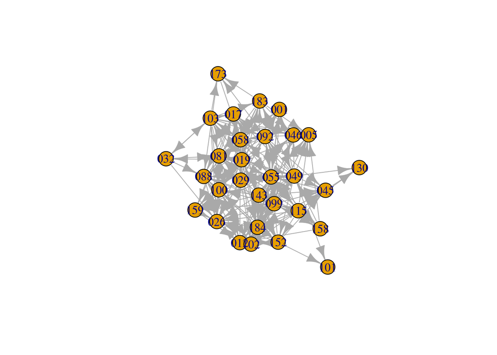

```r
plot(network,layout = layout_with_kk,vertex.label=substr(V(network)$name,5,7))
```

La commande **tkplot** permet de créer un graphe interactif. On trouvera un tutoriel sur la visualisation de graphes sur la page de Katya Ognyanova https://kateto.net/, notamment [ici](https://kateto.net/network-visualization). La page [d’introduction](https://kateto.net/networks-r-igraph) à igraph est particulièrement intéressante.

## Quelques commandes de base

Liste des noeuds

```r
V(network)
```

```
## + 30/30 vertices, named, from 4d1a14a:
##  [1] IND_001 IND_005 IND_012 IND_017 IND_019 IND_026 IND_029 IND_032
##  [9] IND_045 IND_046 IND_049 IND_055 IND_058 IND_081 IND_088 IND_092
## [17] IND_099 IND_100 IND_101 IND_102 IND_103 IND_115 IND_130 IND_143
## [25] IND_152 IND_158 IND_159 IND_173 IND_183 IND_184
```

Liste des arêtes

```r
E(network)
```

```
## + 196/196 edges from 4d1a14a (vertex names):
##  [1] IND_001->IND_055 IND_001->IND_058 IND_001->IND_099 IND_001->IND_100
##  [5] IND_012->IND_026 IND_012->IND_049 IND_012->IND_058 IND_012->IND_152
##  [9] IND_017->IND_088 IND_017->IND_143 IND_019->IND_001 IND_019->IND_005
## [13] IND_019->IND_026 IND_019->IND_032 IND_019->IND_049 IND_019->IND_081
## [17] IND_019->IND_100 IND_019->IND_102 IND_019->IND_103 IND_019->IND_143
## [21] IND_019->IND_152 IND_019->IND_159 IND_019->IND_184 IND_026->IND_081
## [25] IND_029->IND_001 IND_029->IND_017 IND_029->IND_019 IND_029->IND_026
## [29] IND_029->IND_046 IND_029->IND_049 IND_029->IND_055 IND_029->IND_058
## [33] IND_029->IND_081 IND_029->IND_092 IND_029->IND_102 IND_029->IND_103
## [37] IND_029->IND_152 IND_029->IND_159 IND_029->IND_183 IND_029->IND_184
## + ... omitted several edges
```

On peut obtenir sa matrice d’adjacence, par défaut sous la forme d’une matrice creuse. Pour certaines opérations, on privilégiera la forme non creuse.

```r
adj= as_adjacency_matrix(network)
adj[1:10,1:10]
```

```
## 10 x 10 sparse Matrix of class "dgCMatrix"
```

```
##    [[ suppressing 10 column names 'IND_001', 'IND_005', 'IND_012' ... ]]
```

```
##
## IND_001 . . . . . . . . . .
## IND_005 . . . . . . . . . .
## IND_012 . . . . . 1 . . . .
## IND_017 . . . . . . . . . .
## IND_019 1 1 . . . 1 . 1 . .
## IND_026 . . . . . . . . . .
## IND_029 1 . . 1 1 1 . . . 1
## IND_032 . . . . . 1 . . . .
## IND_045 . . . . . . . . . .
## IND_046 . . . . . . . . . .
```

```r
adj= as_adjacency_matrix(network,sparse=F)
adj[1:10,1:10]
```

```
##         IND_001 IND_005 IND_012 IND_017 IND_019 IND_026 IND_029 IND_032
## IND_001       0       0       0       0       0       0       0       0
## IND_005       0       0       0       0       0       0       0       0
## IND_012       0       0       0       0       0       1       0       0
## IND_017       0       0       0       0       0       0       0       0
## IND_019       1       1       0       0       0       1       0       1
## IND_026       0       0       0       0       0       0       0       0
## IND_029       1       0       0       1       1       1       0       0
## IND_032       0       0       0       0       0       1       0       0
## IND_045       0       0       0       0       0       0       0       0
## IND_046       0       0       0       0       0       0       0       0
##         IND_045 IND_046
## IND_001       0       0
## IND_005       0       0
## IND_012       0       0
## IND_017       0       0
## IND_019       0       0
## IND_026       0       0
## IND_029       0       1
## IND_032       0       0
## IND_045       0       0
## IND_046       0       0
```

Des attributs peuvent être associés aux noeuds ainsi qu’aux arêtes.

```r
V(network)$name
```

```
##  [1] "IND_001" "IND_005" "IND_012" "IND_017" "IND_019" "IND_026" "IND_029"
##  [8] "IND_032" "IND_045" "IND_046" "IND_049" "IND_055" "IND_058" "IND_081"
## [15] "IND_088" "IND_092" "IND_099" "IND_100" "IND_101" "IND_102" "IND_103"
## [22] "IND_115" "IND_130" "IND_143" "IND_152" "IND_158" "IND_159" "IND_173"
## [29] "IND_183" "IND_184"
```

```r
vertex_attr(network)
```

```
## $name
##  [1] "IND_001" "IND_005" "IND_012" "IND_017" "IND_019" "IND_026" "IND_029"
##  [8] "IND_032" "IND_045" "IND_046" "IND_049" "IND_055" "IND_058" "IND_081"
## [15] "IND_088" "IND_092" "IND_099" "IND_100" "IND_101" "IND_102" "IND_103"
## [22] "IND_115" "IND_130" "IND_143" "IND_152" "IND_158" "IND_159" "IND_173"
## [29] "IND_183" "IND_184"
```

**Exemple** Ajout d’un attribut sex sur les noeuds (tiré aléatoirement)

```r
V(network)$sex= sample(c("M","F"),gorder(network),replace=T)
vertex_attr(network)
```

```
## $name
##  [1] "IND_001" "IND_005" "IND_012" "IND_017" "IND_019" "IND_026" "IND_029"
##  [8] "IND_032" "IND_045" "IND_046" "IND_049" "IND_055" "IND_058" "IND_081"
## [15] "IND_088" "IND_092" "IND_099" "IND_100" "IND_101" "IND_102" "IND_103"
## [22] "IND_115" "IND_130" "IND_143" "IND_152" "IND_158" "IND_159" "IND_173"
## [29] "IND_183" "IND_184"
##
## $sex
##  [1] "M" "M" "F" "F" "F" "F" "F" "M" "F" "F" "F" "M" "F" "F" "F" "M" "M"
## [18] "M" "F" "F" "F" "F" "F" "F" "M" "M" "M" "F" "M" "M"
```

```r
edge_attr(network)
```

```
## $weight
##   [1] 1 1 1 1 1 1 1 1 1 1 1 1 1 1 1 1 1 1 1 1 1 1 1 1 1 1 1 1 1 1 1 1 1 1 1
##  [36] 1 1 1 1 1 1 1 1 1 1 1 1 1 1 1 1 1 1 1 1 1 1 1 1 1 1 1 1 1 1 1 1 1 1 1
##  [71] 1 1 1 1 1 1 1 1 1 1 1 1 1 1 1 1 1 1 1 1 1 1 1 1 1 1 1 1 1 1 1 1 1 1 1
## [106] 1 1 1 1 1 1 1 1 1 1 1 1 1 1 1 1 1 1 1 1 1 1 1 1 1 1 1 1 1 1 1 1 1 1 1
## [141] 1 1 1 1 1 1 1 1 1 1 1 1 1 1 1 1 1 1 1 1 1 1 1 1 1 1 1 1 1 1 1 1 1 1 1
## [176] 1 1 1 1 1 1 1 1 1 1 1 1 1 1 1 1 1 1 1 1 1
```

```r
E(network)$exchange = "plantule"
edge_attr(network)
```

```
## $weight
##   [1] 1 1 1 1 1 1 1 1 1 1 1 1 1 1 1 1 1 1 1 1 1 1 1 1 1 1 1 1 1 1 1 1 1 1 1
##  [36] 1 1 1 1 1 1 1 1 1 1 1 1 1 1 1 1 1 1 1 1 1 1 1 1 1 1 1 1 1 1 1 1 1 1 1
##  [71] 1 1 1 1 1 1 1 1 1 1 1 1 1 1 1 1 1 1 1 1 1 1 1 1 1 1 1 1 1 1 1 1 1 1 1
## [106] 1 1 1 1 1 1 1 1 1 1 1 1 1 1 1 1 1 1 1 1 1 1 1 1 1 1 1 1 1 1 1 1 1 1 1
## [141] 1 1 1 1 1 1 1 1 1 1 1 1 1 1 1 1 1 1 1 1 1 1 1 1 1 1 1 1 1 1 1 1 1 1 1
## [176] 1 1 1 1 1 1 1 1 1 1 1 1 1 1 1 1 1 1 1 1 1
##
## $exchange
##   [1] "plantule" "plantule" "plantule" "plantule" "plantule" "plantule"
##   [7] "plantule" "plantule" "plantule" "plantule" "plantule" "plantule"
##  [13] "plantule" "plantule" "plantule" "plantule" "plantule" "plantule"
##  [19] "plantule" "plantule" "plantule" "plantule" "plantule" "plantule"
##  [25] "plantule" "plantule" "plantule" "plantule" "plantule" "plantule"
##  [31] "plantule" "plantule" "plantule" "plantule" "plantule" "plantule"
```

[output cut: 27 more lines]

Les commandes delete_edges et add_edges permettent d’ajouter et retirer des arêtes.

```r
gsize(network)
```

```
## [1] 196
```

```r
gsize(add_edges(network,c("IND_088","IND_092") ))
```

```
## [1] 197
```

## Données Tham Thuong d’Emmanuel Pannier

```r
event_tham_duong <- read.csv("event_tham_duong.csv", sep=",",header=T)
dim(event_tham_duong)
```

```
## [1] 104   6
```

```r
node_tham_duong <- read.csv("node_tham_duong.csv", sep=",",header=T)
dim(node_tham_duong)
```

```
## [1] 84 11
```

```r
tham_duong <- graph_from_data_frame(d=event_tham_duong[,c(2,4,5:6)], vertices=node_tham_duong[,c(3,2,4:11)], directed=T)
gorder(tham_duong)
```

```
## [1] 84
```

```r
gsize(tham_duong)
```

```
## [1] 104
```

```r
tkplot(tham_duong)
```

```
## [1] 1
```

```r
vertex_attr_names(tham_duong)
```

```
##  [1] "name"
##  [2] "Label"
##  [3] "village.commune"
##  [4] "interviewed"
##  [5] "year.of.birth"
##  [6] "kind.of.breeder.1..good.reputation.2..nothing.special"
##  [7] "level"
##  [8] "ethnie"
##  [9] "local.authority.1..no.2..village.level.3..commune.level.4..district.level.5..former.authority.retired"
## [10] "X"
```

```r
vertex.attributes(tham_duong,c('1','2'))
```

```
## $name
## [1] "1" "2"
##
## $Label
## [1] "Vi Van Sau"       "Hoang Thanh Bich"
##
## $village.commune
## [1] "Ngoang"    "Duong Quy"
##
## $interviewed
## [1] "Y" "N"
##
## $year.of.birth
## [1] 1960   NA
##
## $kind.of.breeder.1..good.reputation.2..nothing.special
## [1]  1 NA
##
## $level
## [1] 1 2
##
## $ethnie
## [1] "Thai" "Tay"
##
## $local.authority.1..no.2..village.level.3..commune.level.4..district.level.5..former.authority.retired
## [1]  1 NA
##
## $X
## [1] "" ""
```

```r
edge_attr_names(tham_duong)
```

```
## [1] "Type.of.transaction"     "Nature.of.the.material."
```

```r
some_edges = E(tham_duong)[as.character(1:10) %->%as.character(1:10)]
edge_attr(tham_duong,name= "Type.of.transaction",index= some_edges)
```

```
##  [1] "loan"     "loan"     "sale"     "gift"     "gift"     "sale"
##  [7] "gift"     "sale"     "gift"     "gift"     "exchange"
```

# Explorons le réseau Vanuatu de Sophie Caillon

Supposons que S.C. n’a l’opportunité de n’interroger qu’une partie de la population. De plus, pour chaque personne interrogée, S.C. ne peut renseigner que les liens **entrants**. Quel impact auront le budget d’échantillonnage ainsi que la méthode d’échantillonnage sur l’estimation des indicateurs du réseau?

Chargement de quelques fonctions annexes

```r
source("ego_functions.R")
```

On se donne d’abord un budget de 4 noeuds qu’on tire aléatoirement. Cela nous permet de découvrir l’egonetwork associé aux voisins (donneurs) de ces quatre noeuds.

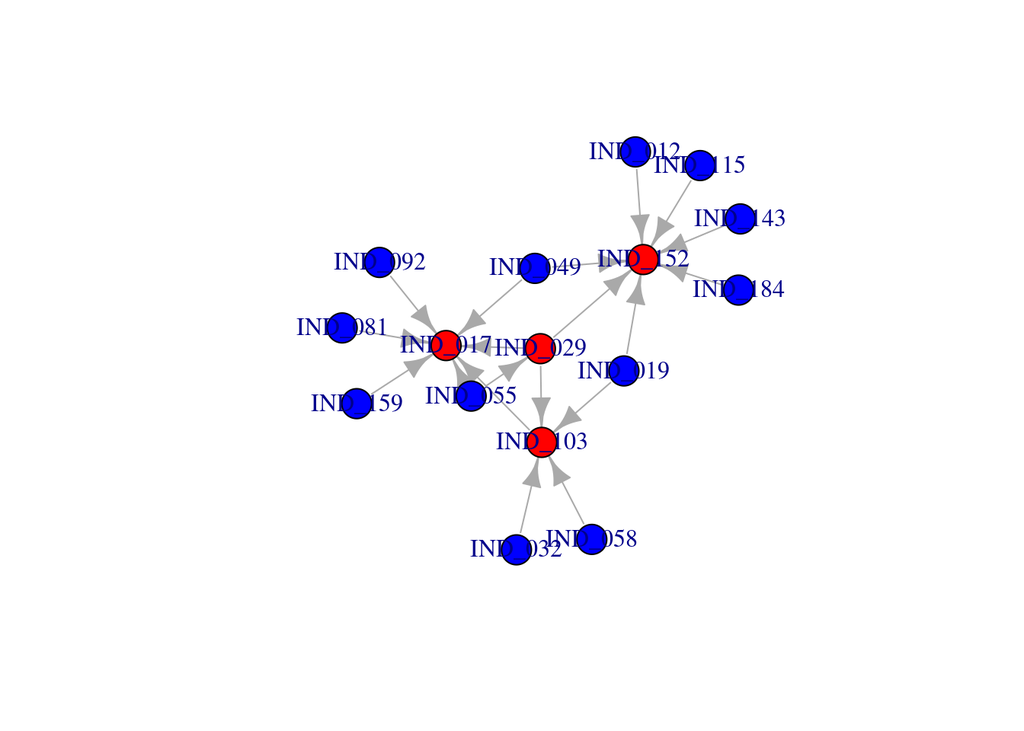

```r
budget = 4
nodes.sampled = sample(V(network), budget)
network.sampled= sample.egonetwork(network,budget, mode="in")
plot(network.sampled)
```

Les noeuds en rouge sont les noeuds effectivement **explorés**. Les noeuds en bleus sont les voisins découvers mais **non explorés** (individus ayant donné des semences à un individu exploré).

Les noeuds de l’objet **network_sampled** ont deux nouveaux attributs: **color** et **explored** qui indiquent si le noeud a été exploré ou pas.

Après cette première phase de terrain, S.C. souhaite visiter 4 individus parmi ceux découverts mais non explorés (méthode du snowball)

```r
budget.2 = 4
nodes.sampled.snow=   sample(neighbors.build(network,nodes.sampled,mode="in"),budget.2)
network.sampled.snow = build_egonetwork(network,unique(c(nodes.sampled,nodes.sampled.snow)),mode="in")
gorder(network.sampled)
```

```
## [1] 16
```

```r
gorder(network.sampled.snow)
```

```
## [1] 26
```

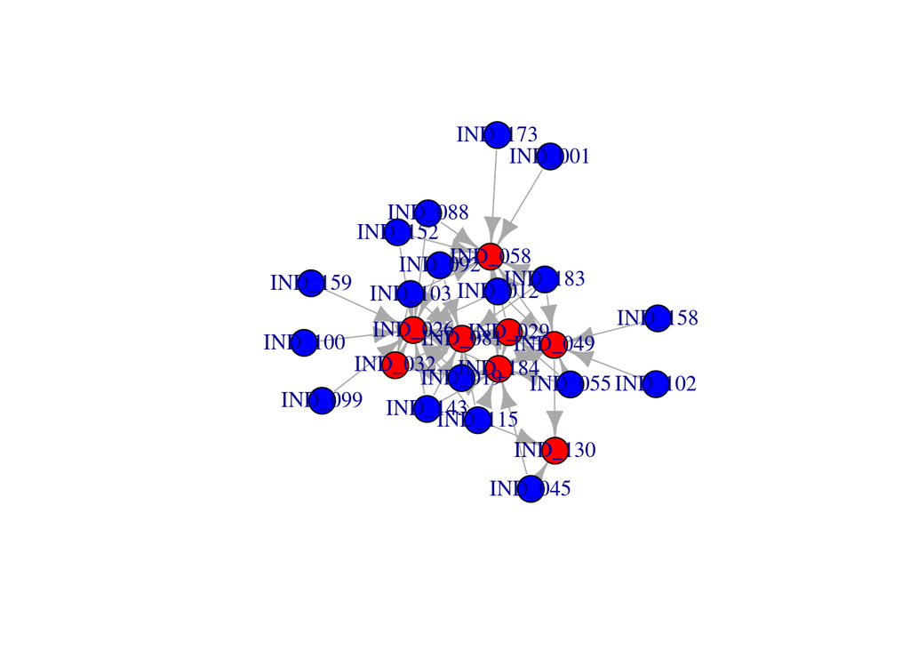

```r
plot(network.sampled.snow)
```

Pour certaines analyses, on utilisera uniquement le sous-réseau restreint aux individus effectivement observés.

```r
## Construction du sous-réseau induit uniquement par les noeuds echantillonné
network.sampled.snow.induced = induced_subgraph(network.sampled.snow,V(network.sampled.snow)[V(network.sampled.snow)$explored==T])
gorder(network.sampled.snow.induced)
```

```
## [1] 8
```

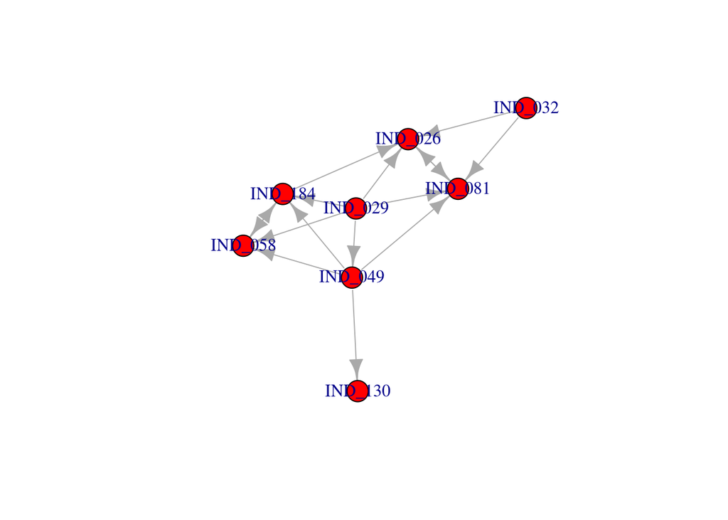

```r
plot(network.sampled.snow.induced)
```

# Compaison de statistiques descriptives sur les réseaux échantillonnés

## Estimation de moyennes et variances des degrés entrants

**Question**: A votre avis, quel mode d’estimation doit-on privilégier?

```r
# pour le réseau entier
deg=degree(network,mode="in")
c(mean(deg),var(deg))
```

```
## [1]  6.533333 12.533333
```

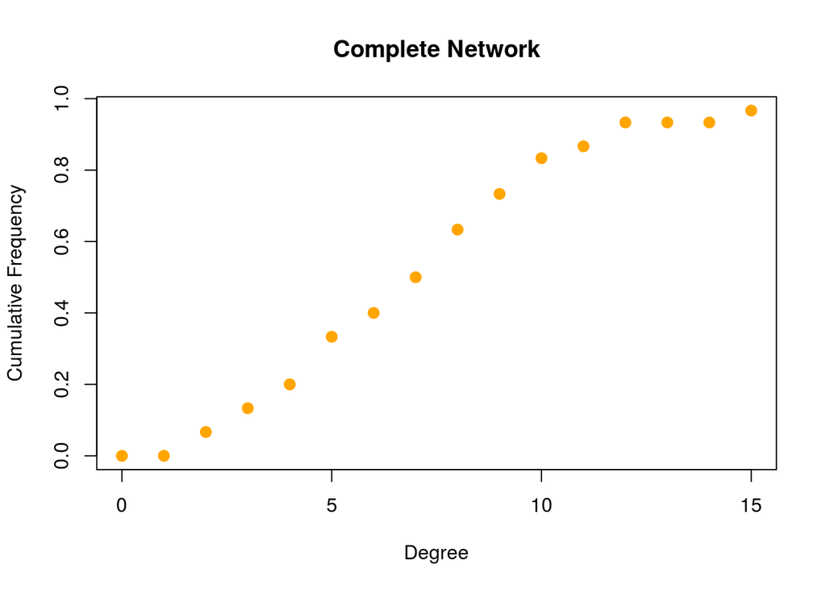

```r
plot( x=0:max(deg), y=1-degree.distribution(network,mode="in",cumulative=T), pch=19, cex=1.2, col="orange", xlab="Degree",ylab="Cumulative Frequency", main= "Complete Network")
```

```r
# pour l'échantillon boule de neige
deg.unc = degree(network.sampled.snow,mode="in")
sort(deg.unc)
```

```
## IND_001 IND_012 IND_019 IND_045 IND_055 IND_088 IND_092 IND_099 IND_100
##       0       0       0       0       0       0       0       0       0
## IND_102 IND_103 IND_115 IND_143 IND_152 IND_158 IND_159 IND_173 IND_183
##       0       0       0       0       0       0       0       0       0
## IND_029 IND_032 IND_130 IND_049 IND_184 IND_081 IND_058 IND_026
##       1       2       3       7       8      10      11      15
```

```r
c(mean(deg.unc),var(deg.unc))
```

```
## [1]  2.192308 17.921538
```

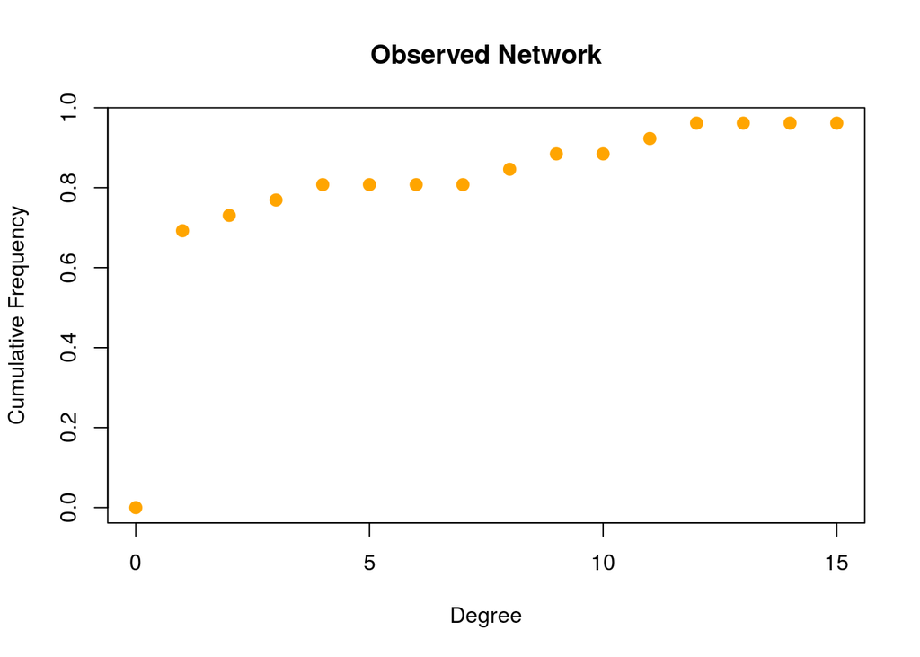

```r
plot( x=0:max(deg.unc), y=1-degree.distribution(network.sampled.snow,mode="in",cumulative=T), pch=19, cex=1.2, col="orange", xlab="Degree",ylab="Cumulative Frequency",main="Observed Network")
```

```r
# pour l'échantillon boule de neige avec correction
deg.cor= degree(network.sampled.snow,mode="in")[V(network.sampled.snow)$explored==T]
sort(deg.cor)
```

```
## IND_029 IND_032 IND_130 IND_049 IND_184 IND_081 IND_058 IND_026
##       1       2       3       7       8      10      11      15
```

```r
c(mean(deg.cor),var(deg.cor))
```

```
## [1]  7.12500 23.83929
```

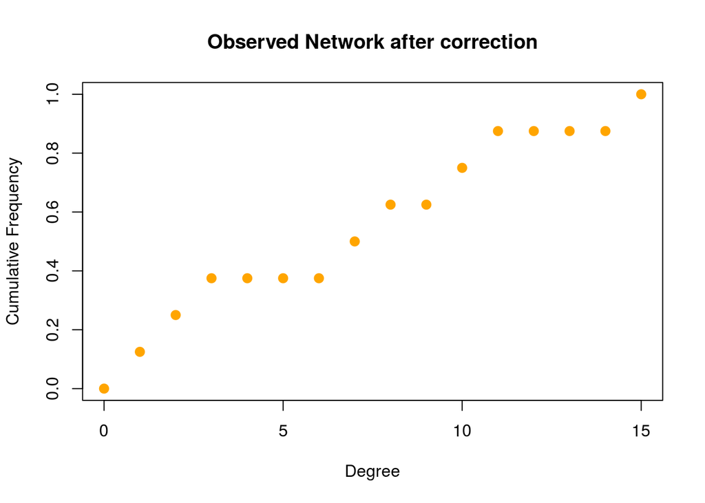

```r
plot( x=0:max(deg.cor), y=(ecdf(deg.cor)(0:max(deg.cor))), pch=19, cex=1.2, col="orange", xlab="Degree",ylab="Cumulative Frequency",main="Observed Network after correction")
```

```r
# pour  le réseau induit
deg.ind= degree(network.sampled.snow.induced,mode="in")
sort(deg.ind)
```

```
## IND_029 IND_032 IND_049 IND_130 IND_058 IND_184 IND_026 IND_081
##       0       0       1       1       3       3       4       4
```

```r
c(mean(deg.ind),var(deg.ind))
```

```
## [1] 2.000000 2.857143
```

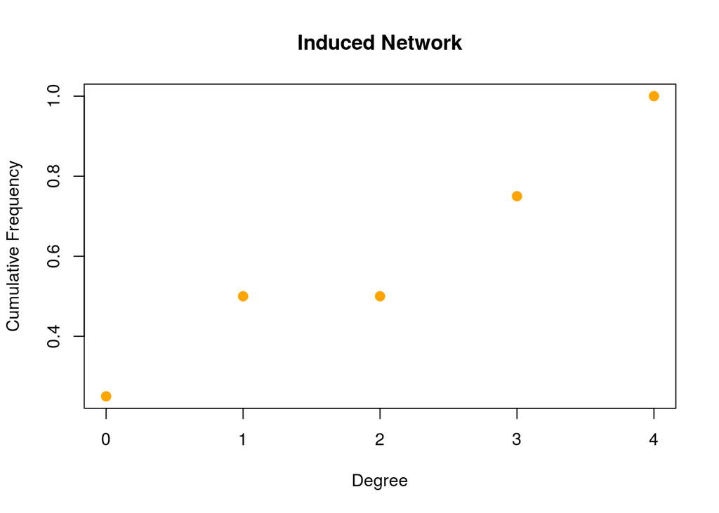

```r
plot( x=0:max(deg.ind), y=(ecdf(deg.ind)(0:max(deg.ind))), pch=19, cex=1.2, col="orange", xlab="Degree",ylab="Cumulative Frequency",main="Induced Network")
```

## Estimation des moyennes et variances des degrés sortants?

**Question** Est-il facile d’estimer ces quantités?

```r
# pour le réseau entier
deg=degree(network,mode="out")
c(mean(deg),var(deg))
```

```
## [1]  6.533333 27.912644
```

```r
# pour l'échantillon boule de neige
deg.unc = degree(network.sampled.snow,mode="out")
sort(deg.unc)
```

```
## IND_130 IND_001 IND_026 IND_058 IND_081 IND_099 IND_100 IND_102 IND_158
##       0       1       1       1       1       1       1       1       1
## IND_159 IND_173 IND_032 IND_045 IND_088 IND_152 IND_184 IND_012 IND_055
##       1       1       2       2       2       2       2       3       3
## IND_092 IND_143 IND_183 IND_049 IND_103 IND_115 IND_019 IND_029
##       3       3       3       4       4       4       5       5
```

```r
c(mean(deg.unc),var(deg.unc))
```

```
## [1] 2.192308 1.921538
```

```r
# pour l'échantillon boule de neige avec correction
deg.cor= degree(network.sampled.snow,mode="out")[V(network.sampled.snow)$explored==T]
sort(deg.cor)
```

```
## IND_130 IND_026 IND_058 IND_081 IND_032 IND_184 IND_049 IND_029
##       0       1       1       1       2       2       4       5
```

```r
c(mean(deg.cor),var(deg.cor))
```

```
## [1] 2.000000 2.857143
```

```r
# pour  le réseau induit
deg.ind= degree(network.sampled.snow.induced,mode="out")
sort(deg.ind)
```

```
## IND_130 IND_026 IND_058 IND_081 IND_032 IND_184 IND_049 IND_029
##       0       1       1       1       2       2       4       5
```

```r
c(mean(deg.ind),var(deg.cor))
```

```
## [1] 2.000000 2.857143
```

## Calcul de la réciprocité

Comment estimer au mieux la réciprocité? Quel mode d’échantillonnage privilégier?s

```r
reciprocity(network.sampled.snow.induced)
```

```
## [1] 0.25
```

```r
reciprocity(network.sampled.snow)
```

```
## [1] 0.07017544
```

```r
reciprocity(network.sampled)
```

```
## [1] 0
```

```r
reciprocity(network)
```

```
## [1] 0.2142857
```

## Calcul de la transitivité

**Question** Comment estimer au mieux la transitivité? Quel mode d’échantillonnage privilégier?

```r
transitivity(network.sampled.snow.induced)
```

```
## [1] 0.5714286
```

```r
transitivity(network.sampled)
```

```
## [1] 0.09836066
```

```r
transitivity(network.sampled.snow)
```

```
## [1] 0.2333333
```

```r
transitivity(network)
```

```
## [1] 0.4988516
```

**Remarque**: on peut eventuellement améliorer l’estimation de la transitivité en considérant tous les triplets qui contiennent au moins 2 noeuds explorés, mais cela requiert d’écrire une fonction ad-hoc.

## Calcul de centralité

On travaille sur une version non dirigée du réseau

```r
network.und= as.undirected(network)
```

Calcul des trois indices de centralité sur le réseau complet

```r
ev.cent<-eigen_centrality(network.und)$vector
clo.cent<-closeness(network.und,normalized=T)
be.cent<-betweenness(network.und,normalized=T)
```

On va se concentrer sur les noeuds explorés et voir dans quels mesures leurs valeurs de centralité sont bien estimées.

```r
# vecteur des noeuds échantillonnés par les deux étapes du snowball
nodes.sampled.snow = sort(unique(c(nodes.sampled,nodes.sampled.snow)))
sort(ev.cent[nodes.sampled.snow])
```

```
##   IND_130   IND_032   IND_058   IND_026   IND_081   IND_029   IND_184
## 0.1230586 0.2233461 0.5405448 0.5897850 0.6323632 0.6769816 0.6867154
##   IND_049
## 0.8811493
```

```r
sort(clo.cent[nodes.sampled.snow])
```

```
##   IND_130   IND_032   IND_058   IND_184   IND_026   IND_081   IND_029
## 0.4531250 0.4677419 0.5918367 0.5918367 0.6170213 0.6444444 0.6590909
##   IND_049
## 0.6904762
```

```r
sort(be.cent[nodes.sampled.snow])
```

```
##     IND_130     IND_032     IND_184     IND_058     IND_026     IND_029
## 0.000223914 0.001332288 0.014551025 0.024953486 0.036996930 0.041767352
##     IND_081     IND_049
## 0.051292014 0.113335158
```

Comparaison des trois indices de centralités (corrélation de Kendall)

`r cor(ev.cent[nodes.sampled.snow],clo.cent[nodes.sampled.snow],method="kendall")`

`## [1] 0.7637626`

`r cor(ev.cent[nodes.sampled.snow],be.cent[nodes.sampled.snow],method="kendall")`

`## [1] 0.6428571`

On calcule maintenant les indices de centralités sur le graphe échantillonné (induit).

```r
ev.cent.snow =eigen_centrality(as.undirected(network.sampled.snow.induced))$vector
clo.cent.snow = closeness(network.sampled.snow.induced,normalized=T)
be.cent.snow = betweenness(as.undirected(network.sampled.snow.induced),normalized=T)
```

Comparaison avec les valeurs calculé à partir du graphe entier.

```r
cor(ev.cent[nodes.sampled.snow],ev.cent.snow,method="kendall")
```

```
## [1] 0.5714286
```

```r
cor(be.cent[nodes.sampled.snow],be.cent.snow,method="kendall")
```

```
## [1] 0.7637626
```

```r
cor(clo.cent[nodes.sampled.snow],clo.cent.snow,method="kendall")
```

```
## [1] 0.4444444
```

# Tests de permutation

Les test par permutation sont simples à réaliser pour le graphe **induit** mais il peut y avoir des problèmes de contraintes lorsque l’échantillonnage est faible.

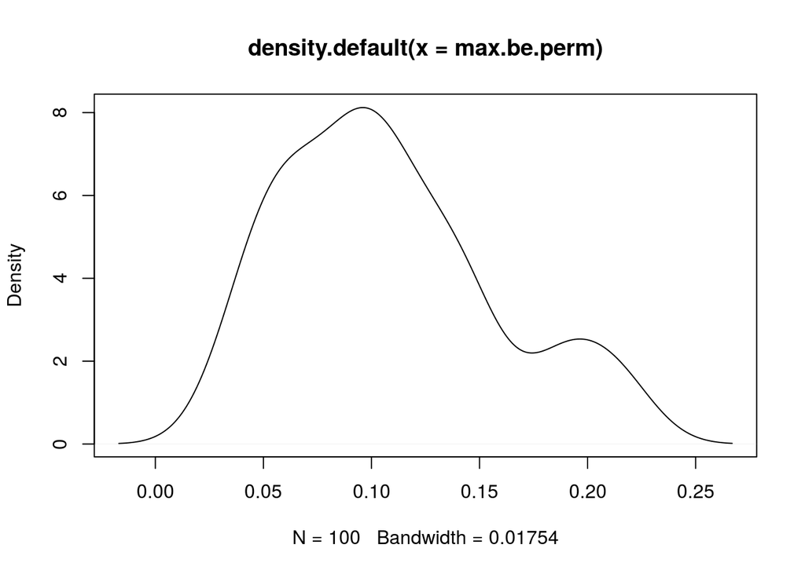

```r
sample.config.directed<-lapply(1:100,function(x) sample_degseq(degree(network.sampled.snow.induced,mode="out"), degree(network.sampled.snow.induced,mode="in"), method = "simple.no.multiple"))
max.be.perm<-sapply(1:100,function(x) max(betweenness(sample.config.directed[[x]],normalized=T)))

plot(density(max.be.perm))
abline(v=max(be.cent.snow),col="red")
```

```r
max.be.perm.distrib<-ecdf(max.be.perm)
1-max.be.perm.distrib(max(be.cent.snow))
```

```
## [1] 0
```

On peut comparer ce test par permutation avec ce qu’on aurait obtenu sur le réseau entier.

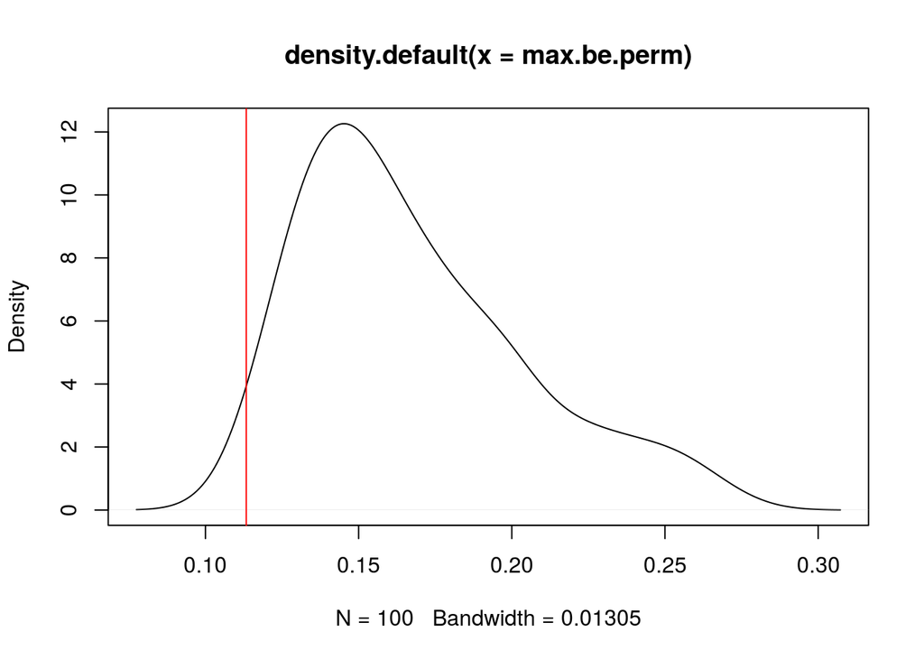

```
## [1] 1
```

# Explorations et comparaisons de plans d’Echantillonnage

On se place maintenant en amont du terrain et on souhaite choisir un **bon** plan d’échantillonnage.

Pour simplifier, on supposera ici que notre critére de qualité est d’estimer au mieux la **transitivité** du réseau (non dirigé), mais la stratégie ici pourra être étendue à d’autres critères.

## Etape 1: Choisir un réseau qui nous semble réaliste

On pourrait prendre des réseaux échantillonnés sur des précédents terrains.

Ici on en choisit deux modéles aléatoires classiques: le graphe géométrique et le graphe à blocs stochastiques. Idéalement on fera varier les paramêtres du modèle afin d’avoir des conclusions plus robustes.

```r
geometric.network= sample_grg(200, 0.1, torus = FALSE, coords = FALSE)
V(geometric.network)$name= as.character(1:200)
tkplot(geometric.network)
```

```
## [1] 2
```

```r
mean(degree(geometric.network))
```

```
## [1] 5.88
```

```r
trans.geom= transitivity(geometric.network)
```

Deuxième modele: un modèle à blocs stochastiques.

```r
prob = matrix(0.01,4,4)
diag(prob)= rep(0.07,4)
sbm.network= sample_sbm(200, prob, rep(50,4))
V(sbm.network)$name= as.character(1:200)
tkplot(sbm.network)
```

```
## [1] 3
```

```r
mean(degree(sbm.network))
```

```
## [1] 5.41
```

```r
transitivity(sbm.network)
```

```
## [1] 0.03
```

## Etape 2: comparaison de méthodes d’échantillonnage.

Questions:

- Quelle est le budget minimal (en nombre de noeuds explorés) permettant d’estimer raisonnablement bien la transitivité?
- Pour un budget donné faut-il privilégier un échantillonnage boule de neige et si oui à combien d’étapes?

```r
budget= seq(24,120,by=12)
```

Comparaison d’échantillonnage d’ego-network, et de snowball à 2, 3 et 4 étapes.

```r
nbr.exp=1
Proba= matrix(0,4,length(budget))
Error= matrix(0,4,length(budget))
colnames(Proba)= budget
colnames(Error)= budget
for (i in 1:(length(budget))){
  transitivity.sampling= sapply(1:nbr.exp,function(x) transitivity(induced.sample(sample.egonetwork(geometric.network,budget[i],mode="all"))))
  Proba[1,i]= sum(is.nan(transitivity.sampling))/nbr.exp
  Error[1,i]=mean(abs((transitivity.sampling- trans.geom)/trans.geom),na.rm=T)
  for (j in 2:4){
    transitivity.sampling= sapply(1:nbr.exp,function(x) transitivity(induced.sample(sample.snowball(geometric.network,j,rep(budget[i]/j,j),mode="all"))))
    Proba[j,i]= sum(is.nan(transitivity.sampling))/nbr.exp
    Error[j,i]=mean(abs((transitivity.sampling- trans.geom)/trans.geom),na.rm=T)
  }
}

Proba # probabilité que l'estimateur produise NaN
```

```
##      24 36 48 60 72 84 96 108 120
## [1,]  0  0  0  0  0  0  0   0   0
## [2,]  0  0  0  0  0  0  0   0   0
## [3,]  0  0  0  0  0  0  0   0   0
## [4,]  0  0  0  0  0  0  0   0   0
```

```r
Error # Erreur relative
```

```
##              24         36          48         60         72          84
## [1,] 0.21627177 0.07377573 0.150961088 0.01884669 0.05854202 0.002716198
## [2,] 0.07247021 0.04497097 0.003409624 0.10035443 0.08884380 0.034521259
## [3,] 0.35846226 0.06266104 0.049720837 0.14344747 0.02949666 0.103296555
## [4,] 0.25709095 0.08283224 0.166149831 0.03687938 0.01735059 0.002716198
##              96         108         120
## [1,] 0.11985305 0.009002765 0.027955158
## [2,] 0.09502215 0.029245719 0.035458326
## [3,] 0.06477831 0.028610502 0.009870072
## [4,] 0.09568709 0.053363697 0.042002301
```

Même comparaison pour le modèle à blocs stochastiques

```
##      24 36 48 60 72 84 96 108 120
## [1,]  0  0  0  0  0  0  0   0   0
## [2,]  0  0  0  0  0  0  0   0   0
## [3,]  0  0  0  0  0  0  0   0   0
## [4,]  0  0  0  0  0  0  0   0   0
```

```
##             24        36        48        60        72        84        96
## [1,] 1.0000000 1.0000000 1.0000000 1.0000000 0.8806039 0.9577242 0.9807765
## [2,] 0.8243368 0.7630589 0.8726442 0.9667044 0.8700451 0.9292468 0.9447780
## [3,] 0.8243368 1.0000000 0.8408052 0.9378752 0.9557023 0.9467965 0.9341263
## [4,] 0.7089009 0.9407647 0.8077648 0.9308475 0.9060105 0.9536888 0.9335947
##            108       120
## [1,] 0.9734675 0.9424845
## [2,] 0.9533495 0.9262596
## [3,] 0.9048615 0.9784143
## [4,] 0.9253288 0.9099362
```

**Pour aller plus loin**: il faudrait tester d’autres paramêtres pour les modèles de réseaux pour en tirer des conclusions plus robustes.